# 克隆性和C-S-R策略对外来植物入侵性的影响

Author

Bi-Cheng Dong and Yan Lv

Published

June 25, 2025

## 简介

分析流程包括：

1. **数据准备**: 加载必要的 R 包，导入并清理数据。

2. **克隆性与入侵性分析**: * 分析克隆有无与 CSR 策略对入侵等级的综合影响。 * 分析克隆有无与 CSR 策略对入侵范围的综合影响。

3. **克隆类型与入侵性分析**: * 分析不同克隆类型（地上/地下）与 CSR 策略对入侵等级的综合影响。 * 分析不同克隆类型（地上/地下）与 CSR 策略对入侵范围的综合影响。

每个分析部分都包含数据建模和可视化两个环节。

## 1. 环境设置与数据导入

首先，我们设置工作目录，并加载本次分析所需的 R 包。

```r
# 加载必要的包
library(AER)
library(broom)
library(ggpubr)
library(MASS)
library(ordinal)
library(patchwork)
library(purrr)
library(tidyverse)

# 设置工作目录
# # 请注意：通常建议使用相对路径或 RStudio 项目来管理工作目录
# setwd("path/to/folder")
setwd("D:/我的坚果云/克隆性和csr策略")
getwd()
```

```
[1] "D:/我的坚果云/克隆性和csr策略"
```

```r
# 检查目录是否存在，如果不存在则创建
if (!dir.exists("results02")) {
  dir.create("results02")
  cat("目录 'results02' 已创建\n")
} else {
  cat("目录 'results02' 已存在\n")
}
```

```
目录 'results02' 已存在
```

接下来，导入数据集。该数据集包含植物的克隆属性、CSR 策略得分以及入侵信息。

```r
# 导入数据
df00 <- read_csv("012.iplant_ias_clonality_csr.csv", locale = locale(encoding = "GB18030"))
glimpse(df00)
```

```
Rows: 212
Columns: 65
$ Taxon_orig                <chr> "Pistia stratiotes", "Eichhornia crassipes",…
$ Taxon_orig.authority      <chr> "L.", "(Mart.) Solms", "L.", "Loisel.", "(L.…
$ 中文名                    <chr> "大薸", "凤眼蓝", "毒麦", "互花米草", "石茅", "光荚含羞草", "土…
$ 拉丁名                    <chr> "Pistia stratiotes", "Eichhornia crassipes",…
$ 科名                      <chr> "天南星科", "雨久花科", "禾本科", "禾本科", "禾本科", "豆科", "…
$ 大类                      <chr> "被子植物", "被子植物", "被子植物", "被子植物", "被子植物", "被子植…
$ 保护等级                  <chr> "1 级（恶意入侵", "1 级（恶意入侵", "1 级（恶意入侵", "1 级（恶意入…
$ href                      <chr> "https://www.plantplus.cn/ias/info/7", "http…
$ match_type                <chr> "Exact (with author)", "Exact (with author)"…
$ multiple_matches          <lgl> FALSE, FALSE, FALSE, FALSE, FALSE, FALSE, FA…
$ match_similarity          <dbl> 1, 1, 1, 1, 1, 1, 1, 1, 1, 1, 1, 1, 1, 1, 1,…
$ match_edit_distance       <dbl> 0, 0, 0, 0, 0, 0, 0, 0, 0, 0, 0, 0, 0, 0, 0,…
$ wcvp_id                   <dbl> 156674, 242133, 422908, 443751, 443460, 2510…
```

[output cut: 52 more lines]

## 2. 克隆性与CSR策略对入侵性的影响

本部分探究克隆与否 (`clonality`) 及 CSR 策略得分 (`c_score`, `s_score`, `r_score`) 如何共同影响入侵等级和入侵范围。

### 2.1 对入侵等级的影响 (有序逻辑回归)

#### 数据处理与模型拟合

我们首先筛选数据，将入侵等级 (`invasion_level`) 和克隆性 (`clonality`) 转换为因子类型，为有序逻辑回归做准备。

```r
# 提取相关数据, 调整分布数据NA为0
df00 <- df00 %>% mutate(n.prov = ifelse(is.na(n.prov), 0, n.prov))

# 去除缺失数据
df01 <- df00 %>%
  filter(!is.na(clonality) & !is.na(c_score) & !is.na(n.prov))

# 将 invasion_level 设置为有序因子
df01$invasion_level <- factor(df01$invasion_level, levels = c(4, 3, 2, 1), ordered = TRUE)
df01$clonality <- factor(df01$clonality, levels = c("non-clonal", "clonal"))

# 检查分类变量的分布
table(df01$invasion_level)
```

```
 4  3  2  1
34 17 29 16
```

```r
nrow(df01)
```

```
[1] 96
```

```r
# 使用 clm 进行有序逻辑回归
fit01.ias.level.c <- clm(invasion_level ~ clonality + c_score + clonality:c_score, data = df01, link = "logit")
fit01.ias.level.s <- clm(invasion_level ~ clonality + s_score + clonality:s_score, data = df01, link = "logit")
fit01.ias.level.r <- clm(invasion_level ~ clonality + r_score + clonality:r_score, data = df01, link = "logit")
```

查看并整理模型结果。

```r
# 输出模型结果
summary(fit01.ias.level.c)
```

```
formula: invasion_level ~ clonality + c_score + clonality:c_score
data:    df01

 link  threshold nobs logLik  AIC    niter max.grad cond.H
 logit flexible  96   -123.56 259.11 5(0)  4.20e-12 8.9e+04

Coefficients:
                        Estimate Std. Error z value Pr(>|z|)
clonalityclonal         -0.19151    0.75018  -0.255   0.7985
c_score                  0.01949    0.01026   1.899   0.0575 .
clonalityclonal:c_score  0.01086    0.01669   0.651   0.5149
---
Signif. codes:  0 '***' 0.001 '**' 0.01 '*' 0.05 '.' 0.1 ' ' 1

Threshold coefficients:
    Estimate Std. Error z value
4|3   0.2209     0.5396   0.409
3|2   1.0001     0.5504   1.817
2|1   2.5568     0.5926   4.314
```

```r
summary(fit01.ias.level.s)
```

```
formula: invasion_level ~ clonality + s_score + clonality:s_score
data:    df01

 link  threshold nobs logLik  AIC    niter max.grad cond.H
 logit flexible  96   -127.69 267.37 5(0)  3.80e-11 1.8e+04

Coefficients:
                          Estimate Std. Error z value Pr(>|z|)
clonalityclonal         -0.3573043  0.5403097  -0.661    0.508
s_score                  0.0009019  0.0128902   0.070    0.944
clonalityclonal:s_score  0.0100280  0.0178135   0.563    0.573

Threshold coefficients:
    Estimate Std. Error z value
4|3  -0.6308     0.3407  -1.851
3|2   0.1071     0.3337   0.321
2|1   1.6018     0.3806   4.209
```

```r
summary(fit01.ias.level.r)
```

```
formula: invasion_level ~ clonality + r_score + clonality:r_score
data:    df01

 link  threshold nobs logLik  AIC    niter max.grad cond.H
 logit flexible  96   -122.45 256.91 5(0)  2.03e-13 6.8e+04

Coefficients:
                         Estimate Std. Error z value Pr(>|z|)
clonalityclonal          0.237554   0.687614   0.345   0.7297
r_score                 -0.021865   0.010780  -2.028   0.0425 *
clonalityclonal:r_score -0.006879   0.015343  -0.448   0.6539
---
Signif. codes:  0 '***' 0.001 '**' 0.01 '*' 0.05 '.' 0.1 ' ' 1

Threshold coefficients:
    Estimate Std. Error z value
4|3  -1.5256     0.4995  -3.054
3|2  -0.7107     0.4751  -1.496
2|1   0.8619     0.4988   1.728
```

```r
# 使用 broom::tidy 提取并合并模型结果
results_fit01.ias.level.c <- broom::tidy(fit01.ias.level.c) %>%
  mutate(model = "fit01.ias.level.c") %>%
  mutate_if(is.numeric, round, 3)

results_fit01.ias.level.s <- broom::tidy(fit01.ias.level.s) %>%
  mutate(model = "fit01.ias.level.s") %>%
  mutate_if(is.numeric, round, 3)

results_fit01.ias.level.r <- broom::tidy(fit01.ias.level.r) %>%
  mutate(model = "fit01.ias.level.r") %>%
  mutate_if(is.numeric, round, 3)

results_fit01.ias.level <- bind_rows(
    results_fit01.ias.level.c,
    results_fit01.ias.level.s,
    results_fit01.ias.level.r
  )

# 结果保存到CSV文件
# write_csv(results_fit01.ias.level, "./results02/results_fit01.ias.level.csv")
head(results_fit01.ias.level)
```

```
# A tibble: 6 × 7
  term                    estimate std.error statistic p.value coef.type model
  <chr>                      <dbl>     <dbl>     <dbl>   <dbl> <chr>     <chr>
1 4|3                        0.221     0.54      0.409   0.682 intercept fit01.…
2 3|2                        1         0.55      1.82    0.069 intercept fit01.…
3 2|1                        2.56      0.593     4.31    0     intercept fit01.…
4 clonalityclonal           -0.192     0.75     -0.255   0.799 location  fit01.…
5 c_score                    0.019     0.01      1.90    0.058 location  fit01.…
6 clonalityclonal:c_score    0.011     0.017     0.651   0.515 location  fit01.…
```

#### 可视化

使用箱线图展示不同克隆性、不同 CSR 策略得分下入侵等级的分布。

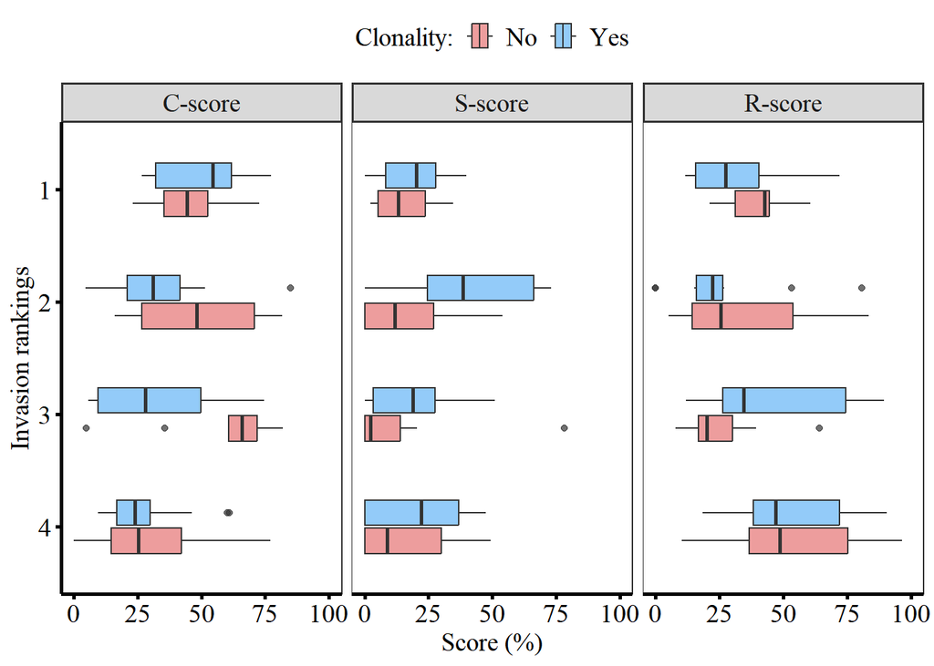

```r
# 转换数据为长格式以方便作图
df01_long <- df01 %>%
  pivot_longer(cols = c(c_score, s_score, r_score),
               names_to = "score_type",
               values_to = "score_value") %>%
   mutate(score_type = factor(score_type, levels = c("c_score", "s_score", "r_score")))

# 自定义分面标题
score_labels <- c("c_score" = "C-score", "r_score" = "R-score", "s_score" = "S-score")

# 使用 facet_wrap 绘图
plot.rank01 <- ggplot(df01_long, aes(x = score_value, y = invasion_level, fill = clonality)) +
  geom_boxplot(width = 0.5, alpha = 0.7) +
  labs(x = "Score (%)", y = "Invasion rankings") +
  scale_fill_manual(
    values = c("non-clonal" = "#E57373", "clonal" = "#64B5F6"),
    name = "Clonality:",
    labels = c("No", "Yes")
  ) +
  facet_wrap(~score_type, scales = "free_x", labeller = as_labeller(score_labels)) +
  scale_x_continuous(limits = c(0, 100)) +
  theme_bw() +
  theme(
    panel.background = element_blank(),
    panel.grid = element_blank(),
    strip.text = element_text(family = "serif", size = 14),
    strip.background = element_rect(size = 1, linetype = "solid"),
    axis.line = element_line(size = 1, linetype = "solid"),
    axis.ticks = element_line(colour = "black", size = 1),
    axis.text = element_text(family = "serif", colour = "black", size = 14),
    axis.title = element_text(family = "serif", colour = "black", size = 14),
    legend.position = "top",
    legend.title = element_text(size = 14, family = "serif"),
    legend.text = element_text(size = 14, family = "serif")
  )
print(plot.rank01)
```

```r
# 保存图像
# ggexport(plot.rank01,
#       filename = "./results02/plot.rank01.png",
#       width = 2400,
#       height = 1200,
#       pointsize = 12,
#       res = 300
# )
```

### 2.2 对入侵范围的影响 (类泊松回归)

#### 数据处理与模型拟合

入侵范围 (`n.prov`) 是计数数据，我们使用广义线性模型 (GLM) 进行拟合。由于数据可能存在过度离散，我们选择 `quasipoisson` 分布。

```r
# 使用广义线性模型（GLM）拟合
fit01.ias.dist.c <- glm(n.prov ~ clonality + c_score + clonality:c_score, data = df01, family = quasipoisson(link = "log"))
fit01.ias.dist.s <- glm(n.prov ~ clonality + s_score + clonality:s_score, data = df01, family = quasipoisson(link = "log"))
fit01.ias.dist.r <- glm(n.prov ~ clonality + r_score + clonality:r_score, data = df01, family = quasipoisson(link = "log"))
```

查看并整理模型结果。

```r
# 输出模型结果
summary(fit01.ias.dist.c)
```

```
Call:
glm(formula = n.prov ~ clonality + c_score + clonality:c_score,
    family = quasipoisson(link = "log"), data = df01)

Deviance Residuals:
    Min       1Q   Median       3Q      Max
-6.8750  -4.8652   0.1737   2.1974   4.6550

Coefficients:
                         Estimate Std. Error t value Pr(>|t|)
(Intercept)              3.218413   0.192563  16.714   <2e-16 ***
clonalityclonal         -0.800250   0.319486  -2.505   0.0140 *
c_score                 -0.007294   0.004192  -1.740   0.0852 .
clonalityclonal:c_score  0.011210   0.007355   1.524   0.1309
---
Signif. codes:  0 '***' 0.001 '**' 0.01 '*' 0.05 '.' 0.1 ' ' 1

(Dispersion parameter for quasipoisson family taken to be 9.636597)

    Null deviance: 1291.0  on 95  degrees of freedom
Residual deviance: 1210.4  on 92  degrees of freedom
AIC: NA

Number of Fisher Scoring iterations: 5
```

```r
summary(fit01.ias.dist.s)
```

```
Call:
glm(formula = n.prov ~ clonality + s_score + clonality:s_score,
    family = quasipoisson(link = "log"), data = df01)

Deviance Residuals:
    Min       1Q   Median       3Q      Max
-6.5187  -5.0089   0.4556   2.4573   4.6825

Coefficients:
                         Estimate Std. Error t value Pr(>|t|)
(Intercept)              3.056216   0.128929  23.705   <2e-16 ***
clonalityclonal         -0.456042   0.239434  -1.905   0.0599 .
s_score                 -0.009599   0.006164  -1.557   0.1229
clonalityclonal:s_score  0.007792   0.008822   0.883   0.3794
---
Signif. codes:  0 '***' 0.001 '**' 0.01 '*' 0.05 '.' 0.1 ' ' 1

(Dispersion parameter for quasipoisson family taken to be 9.76702)

    Null deviance: 1291.0  on 95  degrees of freedom
Residual deviance: 1217.4  on 92  degrees of freedom
AIC: NA

Number of Fisher Scoring iterations: 5
```

```r
summary(fit01.ias.dist.r)
```

```
Call:
glm(formula = n.prov ~ clonality + r_score + clonality:r_score,
    family = quasipoisson(link = "log"), data = df01)

Deviance Residuals:
    Min       1Q   Median       3Q      Max
-6.0502  -4.9696   0.2217   2.4203   4.5845

Coefficients:
                         Estimate Std. Error t value Pr(>|t|)
(Intercept)              2.407852   0.209547  11.491   <2e-16 ***
clonalityclonal          0.209862   0.320265   0.655   0.5139
r_score                  0.011592   0.003903   2.970   0.0038 **
clonalityclonal:r_score -0.013123   0.006437  -2.039   0.0443 *
---
Signif. codes:  0 '***' 0.001 '**' 0.01 '*' 0.05 '.' 0.1 ' ' 1

(Dispersion parameter for quasipoisson family taken to be 9.470956)

    Null deviance: 1291.0  on 95  degrees of freedom
Residual deviance: 1162.4  on 92  degrees of freedom
AIC: NA

Number of Fisher Scoring iterations: 5
```

```r
# 使用 broom::tidy 提取并合并模型结果
results_fit01.ias.dist.c <- broom::tidy(fit01.ias.dist.c) %>%
  mutate(model = "fit01.ias.dist.c") %>%
  mutate_if(is.numeric, round, 3)

results_fit01.ias.dist.s <- broom::tidy(fit01.ias.dist.s) %>%
  mutate(model = "fit01.ias.dist.s") %>%
  mutate_if(is.numeric, round, 3)

results_fit01.ias.dist.r <- broom::tidy(fit01.ias.dist.r) %>%
  mutate(model = "fit01.ias.dist.r") %>%
  mutate_if(is.numeric, round, 3)

results_fit01.ias.dist <- bind_rows(
    results_fit01.ias.dist.c,
    results_fit01.ias.dist.s,
    results_fit01.ias.dist.r
  )

# 结果保存到CSV文件
# write_csv(results_fit01.ias.dist, "./results02/results_fit01.ias.dist.csv")
head(results_fit01.ias.dist)
```

```
# A tibble: 6 × 6
  term                    estimate std.error statistic p.value model
  <chr>                      <dbl>     <dbl>     <dbl>   <dbl> <chr>
1 (Intercept)                3.22      0.193     16.7    0     fit01.ias.dist.c
2 clonalityclonal           -0.8       0.319     -2.50   0.014 fit01.ias.dist.c
3 c_score                   -0.007     0.004     -1.74   0.085 fit01.ias.dist.c
4 clonalityclonal:c_score    0.011     0.007      1.52   0.131 fit01.ias.dist.c
5 (Intercept)                3.06      0.129     23.7    0     fit01.ias.dist.s
6 clonalityclonal           -0.456     0.239     -1.90   0.06  fit01.ias.dist.s
```

#### 可视化

为了可视化模型结果，我们生成预测数据，并在散点图上绘制拟合曲线。

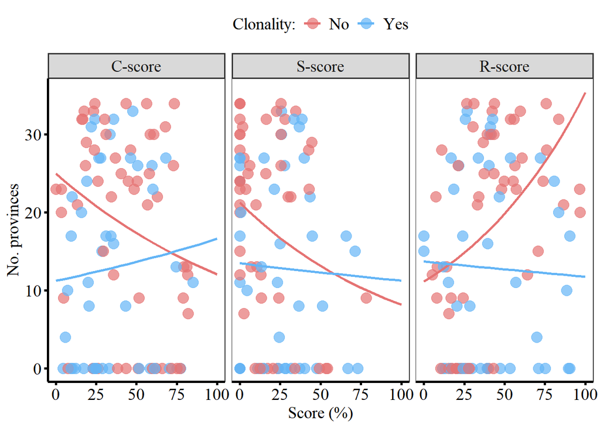

```r
# 定义评分变量和类型
score_types <- c("c_score", "s_score", "r_score")
score_seq <- seq(0, 100, length.out = 21)

# 使用map批量拟合模型并生成预测数据
fit01.ias.dist <- map(score_types, function(var) {
  formula <- as.formula(paste("n.prov ~ clonality +", var, "+ clonality:", var))
  glm(formula, data = df01, family = quasipoisson(link = "log"))
})
names(fit01.ias.dist) <- score_types

pred01_list <- map2(score_types, fit01.ias.dist, function(var_name, model) {
  var_grid <- setNames(list(score_seq, unique(df01$clonality)), c(var_name, "clonality"))
  new_data <- do.call(expand.grid, var_grid)
  new_data$n.prov <- predict(model, newdata = new_data, type = "response")
  new_data$score_type <- var_name
  new_data$score_value <- new_data[[var_name]]
  new_data[[var_name]] <- NULL
  return(new_data)
})

pred01_long <- bind_rows(pred01_list) %>%
  arrange(score_type, clonality, score_value) %>%
  mutate(score_type = factor(score_type, levels = c("c_score", "s_score", "r_score")))

# 绘图
plot.dist01 <- ggplot(df01_long, aes(x = score_value, y = n.prov, color = clonality)) +
  geom_point(alpha = 0.7, size = 4) +
  geom_line(data = pred01_long, aes(x = score_value, y = n.prov), size = 1) +
  labs(x = "Score (%)", y = "No. provinces") +
  scale_color_manual(
    values = c("non-clonal" = "#E57373", "clonal" = "#64B5F6"),
    name = "Clonality:",
    labels = c("No", "Yes")
  ) +
  facet_wrap(~score_type, scales = "free_x", labeller = as_labeller(score_labels)) +
  scale_x_continuous(limits = c(0, 100)) +
  theme_bw() +
  theme(
    panel.background = element_blank(),
    panel.grid = element_blank(),
    strip.text = element_text(family = "serif", size = 14),
    strip.background = element_rect(size = 1, linetype = "solid"),
    axis.line = element_line(size = 1, linetype = "solid"),
    axis.ticks = element_line(colour = "black", size = 1),
    axis.text = element_text(family = "serif", colour = "black", size = 14),
    axis.title = element_text(family = "serif", colour = "black", size = 14),
    legend.position = "top",
    legend.title = element_text(size = 14, family = "serif"),
    legend.text = element_text(size = 14, family = "serif")
  )
print(plot.dist01)
```

```r
# 保存图像
# ggexport(plot.dist01,
#          filename = "./results02/plot.dist01.png",
#          width = 2400,
#          height = 1200,
#          pointsize = 12,
#          res = 300
# )
```

### 2.3 汇总图

将入侵等级和入侵范围的图合并展示。

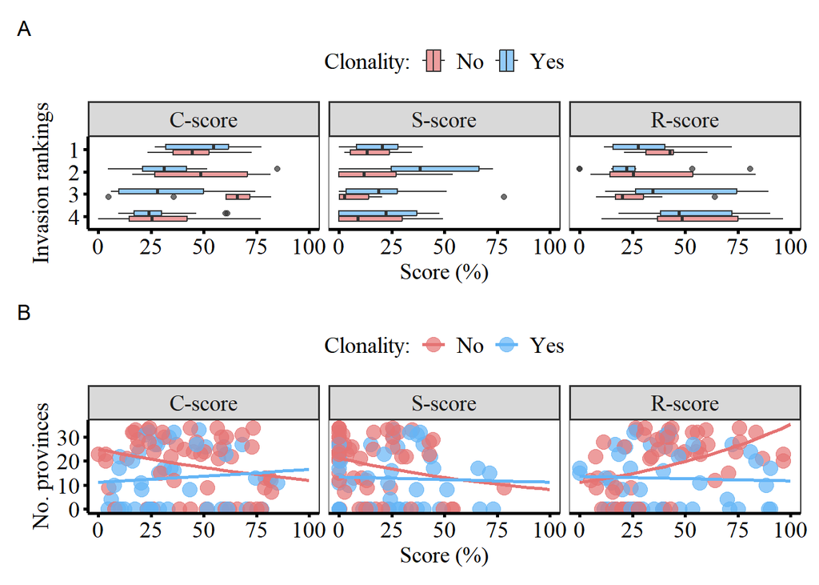

```r
# 汇总图
plot01 <- plot.rank01 +
          plot.dist01 +
          plot_layout(ncol = 1) +
          plot_annotation(tag_levels = 'A')

print(plot01)
```

```r
# 保存汇总图
# ggexport(plot01,
#          filename = "./results02/plot01.png",
#          width = 2400,
#          height = 2400,
#          pointsize = 12,
#          res = 300
# )
```

## 3. 克隆类型与CSR策略对入侵性的影响

本部分进一步细分克隆植物，探究不同克隆类型 (`clonal_type`: 地上/地下) 与 CSR 策略如何影响入侵性。

### 3.1 对入侵等级的影响 (有序逻辑回归)

#### 数据处理与模型拟合

筛选出具有明确地上或地下克隆器官的物种，并构建有序逻辑回归模型。

```r
# 筛选有效数据
df02 <- df00 %>%
  filter(clonal_type %in% c("aboveground", "belowground")) %>%
  filter(!is.na(clonal_type) & !is.na(c_score) & !is.na(n.prov))

table(df02$clonal_type)
```

```
aboveground belowground
         19          19
```

```r
nrow(df02)
```

```
[1] 38
```

```r
# 将变量设置为因子
df02$invasion_level <- factor(df02$invasion_level, levels = c(4, 3, 2, 1), ordered = TRUE)
df02$clonal_type <- factor(df02$clonal_type, levels = c("aboveground", "belowground"))

# 模型拟合
fit02.ias.level.c <- clm(invasion_level ~ clonal_type + c_score + clonal_type:c_score, data = df02, link = "logit")
fit02.ias.level.s <- clm(invasion_level ~ clonal_type + s_score + clonal_type:s_score, data = df02, link = "logit")
fit02.ias.level.r <- clm(invasion_level ~ clonal_type + r_score + clonal_type:r_score, data = df02, link = "logit")
```

查看并整理模型结果。

```r
# 输出模型结果
summary(fit02.ias.level.c)
```

```
formula: invasion_level ~ clonal_type + c_score + clonal_type:c_score
data:    df02

 link  threshold nobs logLik AIC    niter max.grad cond.H
 logit flexible  38   -48.57 109.14 4(0)  2.23e-09 7.5e+04

Coefficients:
                                Estimate Std. Error z value Pr(>|z|)
clonal_typebelowground         -1.006408   1.243485  -0.809    0.418
c_score                         0.033998   0.025853   1.315    0.188
clonal_typebelowground:c_score  0.005721   0.031899   0.179    0.858

Threshold coefficients:
    Estimate Std. Error z value
4|3  0.06879    0.73666   0.093
3|2  1.03910    0.74333   1.398
2|1  2.45955    0.84714   2.903
```

```r
summary(fit02.ias.level.s)
```

```
formula: invasion_level ~ clonal_type + s_score + clonal_type:s_score
data:    df02

 link  threshold nobs logLik AIC    niter max.grad cond.H
 logit flexible  38   -50.96 113.91 4(0)  1.01e-09 2.8e+04

Coefficients:
                               Estimate Std. Error z value Pr(>|z|)
clonal_typebelowground          0.62514    0.94424   0.662    0.508
s_score                         0.01801    0.01593   1.130    0.258
clonal_typebelowground:s_score -0.01797    0.03162  -0.568    0.570

Threshold coefficients:
    Estimate Std. Error z value
4|3  -0.0843     0.6559  -0.129
3|2   0.8183     0.6724   1.217
2|1   2.1242     0.7477   2.841
```

```r
summary(fit02.ias.level.r)
```

```
formula: invasion_level ~ clonal_type + r_score + clonal_type:r_score
data:    df02

 link  threshold nobs logLik AIC    niter max.grad cond.H
 logit flexible  38   -47.72 107.44 4(0)  4.82e-09 6.5e+04

Coefficients:
                               Estimate Std. Error z value Pr(>|z|)
clonal_typebelowground          0.25539    1.11277   0.230   0.8185
r_score                        -0.02733    0.01523  -1.794   0.0728 .
clonal_typebelowground:r_score -0.01600    0.02664  -0.600   0.5482
---
Signif. codes:  0 '***' 0.001 '**' 0.01 '*' 0.05 '.' 0.1 ' ' 1

Threshold coefficients:
    Estimate Std. Error z value
4|3  -1.9998     0.8525  -2.346
3|2  -0.9602     0.7879  -1.219
2|1   0.4864     0.7871   0.618
```

```r
# 使用 broom::tidy 提取并合并模型结果
results_fit02.ias.level.c <- broom::tidy(fit02.ias.level.c) %>%
  mutate(model = "fit02.ias.level.c") %>%
  mutate_if(is.numeric, round, 3)

results_fit02.ias.level.s <- broom::tidy(fit02.ias.level.s) %>%
  mutate(model = "fit02.ias.level.s") %>%
  mutate_if(is.numeric, round, 3)

results_fit02.ias.level.r <- broom::tidy(fit02.ias.level.r) %>%
  mutate(model = "fit02.ias.level.r") %>%
  mutate_if(is.numeric, round, 3)

results_fit02.ias.level <- bind_rows(
    results_fit02.ias.level.c,
    results_fit02.ias.level.s,
    results_fit02.ias.level.r
  )

# 保存结果
# write_csv(results_fit02.ias.level, "./results02/results_fit02.ias.level.csv")
head(results_fit02.ias.level)
```

```
# A tibble: 6 × 7
  term                      estimate std.error statistic p.value coef.type model
  <chr>                        <dbl>     <dbl>     <dbl>   <dbl> <chr>     <chr>
1 4|3                          0.069     0.737     0.093   0.926 intercept fit0…
2 3|2                          1.04      0.743     1.40    0.162 intercept fit0…
3 2|1                          2.46      0.847     2.90    0.004 intercept fit0…
4 clonal_typebelowground      -1.01      1.24     -0.809   0.418 location  fit0…
5 c_score                      0.034     0.026     1.32    0.188 location  fit0…
6 clonal_typebelowground:c…    0.006     0.032     0.179   0.858 location  fit0…
```

#### 可视化

使用箱线图展示不同克隆类型、不同 CSR 策略得分下入侵等级的分布。

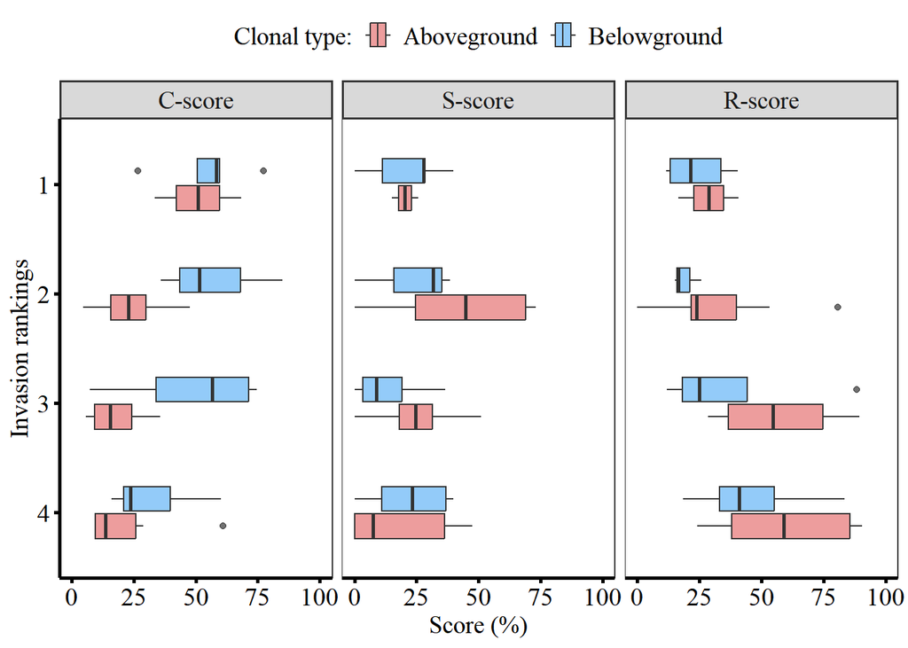

```r
# 转换数据为长格式
df02_long <- df02 %>%
  pivot_longer(cols = c(c_score, s_score, r_score),
               names_to = "score_type",
               values_to = "score_value") %>%
   mutate(score_type = factor(score_type, levels = c("c_score", "s_score", "r_score")))

# 绘图
plot.rank02 <- ggplot(df02_long, aes(x = score_value, y = invasion_level, fill = clonal_type)) +
  geom_boxplot(width = 0.5, alpha = 0.7) +
  labs(x = "Score (%)", y = "Invasion rankings") +
  scale_fill_manual(
    values = c("aboveground" = "#E57373", "belowground" = "#64B5F6"),
    name = "Clonal type:",
    labels = c("Aboveground", "Belowground")
  ) +
  facet_wrap(~score_type, scales = "free_x", labeller = as_labeller(score_labels)) +
  scale_x_continuous(limits = c(0, 100)) +
  theme_bw() +
  theme(
    panel.background = element_blank(),
    panel.grid = element_blank(),
    strip.text = element_text(family = "serif", size = 14),
    strip.background = element_rect(size = 1, linetype = "solid"),
    axis.line = element_line(size = 1, linetype = "solid"),
    axis.ticks = element_line(colour = "black", size = 1),
    axis.text = element_text(family = "serif", colour = "black", size = 14),
    axis.title = element_text(family = "serif", colour = "black", size = 14),
    legend.position = "top",
    legend.title = element_text(size = 14, family = "serif"),
    legend.text = element_text(size = 14, family = "serif")
  )

print(plot.rank02)
```

```r
# 保存图像
# ggexport(plot.rank02,
#       filename = "./results02/plot.rank02.png",
#       width = 2400,
#       height = 1200,
#       pointsize = 12,
#       res = 300
# )
```

### 3.2 对入侵范围的影响 (类泊松回归)

#### 数据处理与模型拟合

与上一部分类似，我们使用类泊松回归模型分析克隆类型与 CSR 策略对入侵范围的影响。

```r
# 模型拟合
fit02.ias.dist.c <- glm(n.prov ~ clonal_type + c_score + clonal_type:c_score, data = df02, family = quasipoisson(link = "log"))
fit02.ias.dist.s <- glm(n.prov ~ clonal_type + s_score + clonal_type:s_score, data = df02, family = quasipoisson(link = "log"))
fit02.ias.dist.r <- glm(n.prov ~ clonal_type + r_score + clonal_type:r_score, data = df02, family = quasipoisson(link = "log"))
```

查看并整理模型结果。

```r
# 输出模型结果
summary(fit02.ias.dist.c)
```

```
Call:
glm(formula = n.prov ~ clonal_type + c_score + clonal_type:c_score,
    family = quasipoisson(link = "log"), data = df02)

Deviance Residuals:
    Min       1Q   Median       3Q      Max
-6.6248  -4.1517  -0.0892   2.9162   4.2441

Coefficients:
                               Estimate Std. Error t value Pr(>|t|)
(Intercept)                     1.82057    0.42678   4.266  0.00015 ***
clonal_typebelowground          1.18613    0.60968   1.945  0.06002 .
c_score                         0.02075    0.01104   1.879  0.06879 .
clonal_typebelowground:c_score -0.02934    0.01447  -2.028  0.05046 .
---
Signif. codes:  0 '***' 0.001 '**' 0.01 '*' 0.05 '.' 0.1 ' ' 1

(Dispersion parameter for quasipoisson family taken to be 10.93902)

    Null deviance: 532.83  on 37  degrees of freedom
Residual deviance: 482.26  on 34  degrees of freedom
AIC: NA

Number of Fisher Scoring iterations: 5
```

```r
summary(fit02.ias.dist.s)
```

```
Call:
glm(formula = n.prov ~ clonal_type + s_score + clonal_type:s_score,
    family = quasipoisson(link = "log"), data = df02)

Deviance Residuals:
    Min       1Q   Median       3Q      Max
-5.2929  -4.8372  -0.7741   2.8779   5.2237

Coefficients:
                                Estimate Std. Error t value Pr(>|t|)
(Intercept)                     2.525351   0.358382   7.047  3.9e-08 ***
clonal_typebelowground          0.114244   0.502486   0.227    0.822
s_score                        -0.003885   0.010013  -0.388    0.700
clonal_typebelowground:s_score  0.003676   0.016954   0.217    0.830
---
Signif. codes:  0 '***' 0.001 '**' 0.01 '*' 0.05 '.' 0.1 ' ' 1

(Dispersion parameter for quasipoisson family taken to be 12.00388)

    Null deviance: 532.83  on 37  degrees of freedom
Residual deviance: 525.32  on 34  degrees of freedom
AIC: NA

Number of Fisher Scoring iterations: 5
```

```r
summary(fit02.ias.dist.r)
```

```
Call:
glm(formula = n.prov ~ clonal_type + r_score + clonal_type:r_score,
    family = quasipoisson(link = "log"), data = df02)

Deviance Residuals:
    Min       1Q   Median       3Q      Max
-5.3477  -4.7376  -0.7812   2.8117   4.7440

Coefficients:
                                Estimate Std. Error t value Pr(>|t|)
(Intercept)                     2.742207   0.437847   6.263 3.93e-07 ***
clonal_typebelowground         -0.388899   0.591190  -0.658    0.515
r_score                        -0.007549   0.009103  -0.829    0.413
clonal_typebelowground:r_score  0.015354   0.012636   1.215    0.233
---
Signif. codes:  0 '***' 0.001 '**' 0.01 '*' 0.05 '.' 0.1 ' ' 1

(Dispersion parameter for quasipoisson family taken to be 11.97407)

    Null deviance: 532.83  on 37  degrees of freedom
Residual deviance: 509.66  on 34  degrees of freedom
AIC: NA

Number of Fisher Scoring iterations: 6
```

```r
# 使用 broom::tidy 提取并合并模型结果
results_fit02.ias.dist.c <- broom::tidy(fit02.ias.dist.c) %>%
  mutate(model = "fit02.ias.dist.c") %>%
  mutate_if(is.numeric, round, 3)

results_fit02.ias.dist.s <- broom::tidy(fit02.ias.dist.s) %>%
  mutate(model = "fit02.ias.dist.s") %>%
  mutate_if(is.numeric, round, 3)

results_fit02.ias.dist.r <- broom::tidy(fit02.ias.dist.r) %>%
  mutate(model = "fit02.ias.dist.r") %>%
  mutate_if(is.numeric, round, 3)

results_fit02.ias.dist <- bind_rows(
    results_fit02.ias.dist.c,
    results_fit02.ias.dist.s,
    results_fit02.ias.dist.r
  )

# 保存结果
# write_csv(results_fit02.ias.dist, "./results02/results_fit02.ias.dist.csv")
head(results_fit02.ias.dist)
```

```
# A tibble: 6 × 6
  term                           estimate std.error statistic p.value model
  <chr>                             <dbl>     <dbl>     <dbl>   <dbl> <chr>
1 (Intercept)                       1.82      0.427     4.27    0     fit02.ias…
2 clonal_typebelowground            1.19      0.61      1.94    0.06  fit02.ias…
3 c_score                           0.021     0.011     1.88    0.069 fit02.ias…
4 clonal_typebelowground:c_score   -0.029     0.014    -2.03    0.05  fit02.ias…
5 (Intercept)                       2.52      0.358     7.05    0     fit02.ias…
6 clonal_typebelowground            0.114     0.502     0.227   0.822 fit02.ias…
```

#### 可视化

生成预测数据，并在散点图上绘制不同克隆类型的拟合曲线。

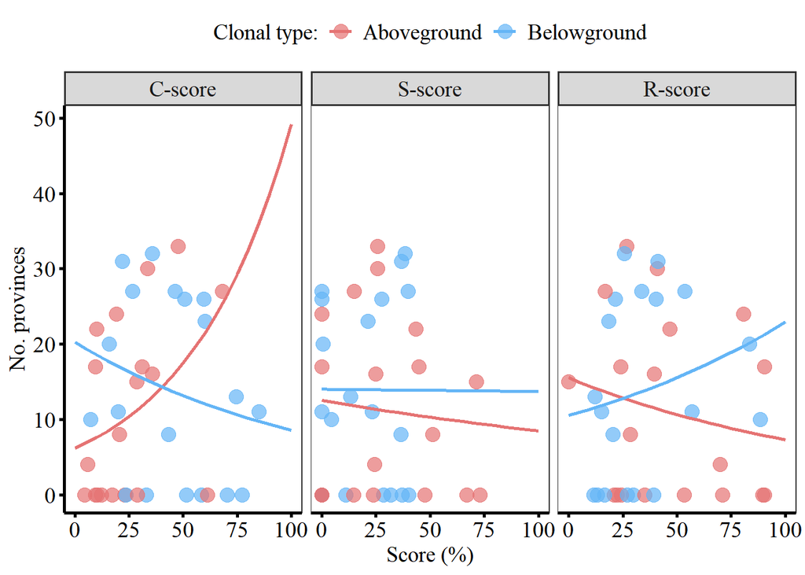

```r
# 定义评分变量和类型
score_types <- c("c_score", "s_score", "r_score")
score_seq <- seq(0, 100, length.out = 21)

# 使用map批量拟合模型并生成预测数据
fit02.ias.dist <- map(score_types, function(var) {
  formula <- as.formula(paste("n.prov ~ clonal_type +", var, "+ clonal_type:", var))
  glm(formula, data = df02, family = quasipoisson(link = "log"))
})
names(fit02.ias.dist) <- score_types

pred02_list <- map2(score_types, fit02.ias.dist, function(var_name, model) {
  var_grid <- setNames(list(score_seq, unique(df02$clonal_type)), c(var_name, "clonal_type"))
  new_data <- do.call(expand.grid, var_grid)
  new_data$n.prov <- predict(model, newdata = new_data, type = "response")
  new_data$score_type <- var_name
  new_data$score_value <- new_data[[var_name]]
  new_data[[var_name]] <- NULL
  return(new_data)
})

pred02_long <- bind_rows(pred02_list) %>%
  arrange(score_type, clonal_type, score_value) %>%
  mutate(score_type = factor(score_type, levels = c("c_score", "s_score", "r_score")))

# 绘图
plot.dist02 <- ggplot(df02_long, aes(x = score_value, y = n.prov, color = clonal_type)) +
  geom_point(alpha = 0.7, size = 4) +
  geom_line(data = pred02_long, aes(x = score_value, y = n.prov), size = 1) +
  labs(x = "Score (%)", y = "No. provinces") +
  scale_color_manual(
    values = c("aboveground" = "#E57373", "belowground" = "#64B5F6"),
    name = "Clonal type:",
    labels = c("Aboveground", "Belowground")
  ) +
  facet_wrap(~score_type, scales = "free_x", labeller = as_labeller(score_labels)) +
  scale_x_continuous(limits = c(0, 100)) +
  theme_bw() +
  theme(
    panel.background = element_blank(),
    panel.grid = element_blank(),
    strip.text = element_text(family = "serif", size = 14),
    strip.background = element_rect(size = 1, linetype = "solid"),
    axis.line = element_line(size = 1, linetype = "solid"),
    axis.ticks = element_line(colour = "black", size = 1),
    axis.text = element_text(family = "serif", colour = "black", size = 14),
    axis.title = element_text(family = "serif", colour = "black", size = 14),
    legend.position = "top",
    legend.title = element_text(size = 14, family = "serif"),
    legend.text = element_text(size = 14, family = "serif")
  )

print(plot.dist02)
```

```r
# 保存图像
# ggexport(plot.dist02,
#       filename = "./results02/plot.dist02.png",
#       width = 2400,
#       height = 1200,
#       pointsize = 12,
#       res = 300
# )
```

### 3.3 汇总图

将关于克隆类型的入侵等级和入侵范围的图合并展示。

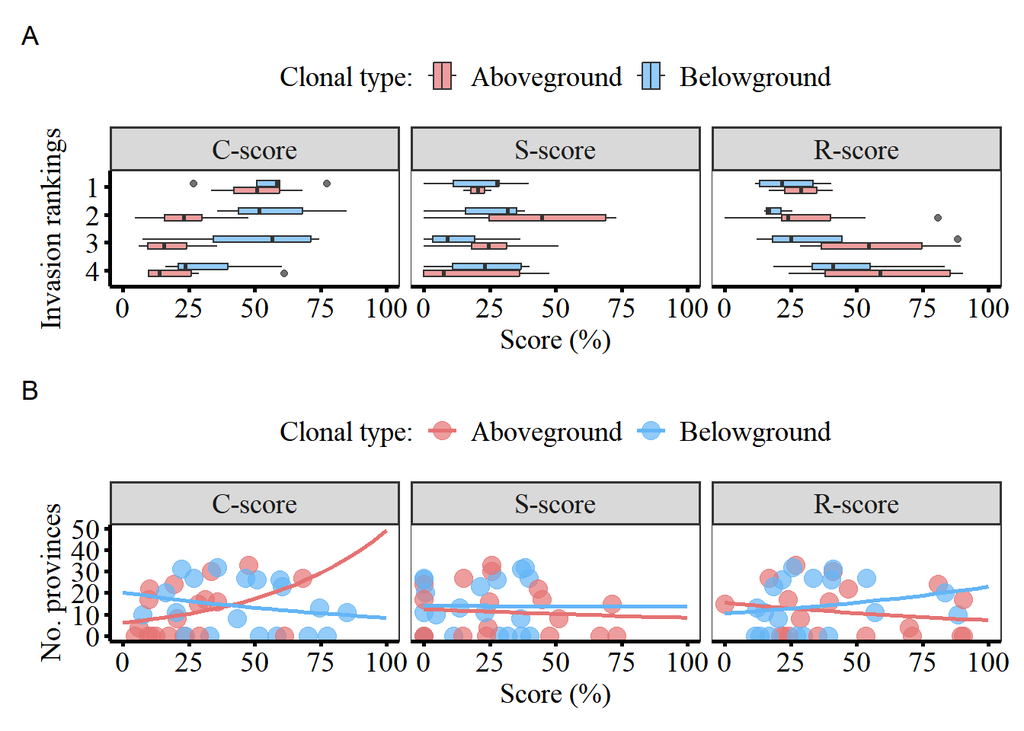

```r
# 汇总图
plot02 <- plot.rank02 +
          plot.dist02 +
          plot_layout(ncol = 1) +
          plot_annotation(tag_levels = 'A')

print(plot02)
```

```r
# 保存汇总图
# ggexport(plot02,
#          filename = "./results02/plot02.png",
#          width = 2400,
#          height = 2400,
#          pointsize = 12,
#          res = 300
# )
```